# Analysis of Bryophyte Richness and Diversity in the Americas

Jackie O’Malley, Julia Eckberg, Andrew Kerkhoff, and Carter Powell

```r
require(knitr)
require(sp)
require(vegan)
require(raster)
require(wesanderson)
require(ggplot2)
require(gridExtra)
```

As an extension of the work done by Carter Powell ’20, who mapped alpha diversity of bryophytes in the Americas using species distribution data from the BIEN database, we have calculated and mapped beta diversity of bryophytes in the Western Hemisphere.

Our analysis begins with bryophyte presence data from BIEN, which was constructed through species distribution modeling based on occurrence records for 4,802 species. We convert this data to a species-by-cell presence-absence matrix in order to calculate beta diversity using the ‘betadiver’ function from the *vegan* package. The resulting “BetaMat.rds” file is a Jacccard similarity matrix showing the beta diversity for each pair of cells. Additionally, we load a blank raster file containing 100km by 100km cells, a numeric vector equal to the number of cells in the raster, cell richness (alpha diversity) data, and a vector of the Cell IDs for each occuppied cell.

```r
BlankRas <-raster("Data/blank_100km_raster.tif")
CellRichness <- readRDS("Data/CellRichness.rds")
CellID <- CellRichness$CellID
CellVec <- c(1:15038)

BetaMat <- readRDS("Data/BetaMat.rds")
BetaMat<-as.matrix(BetaMat)
row.names(BetaMat) <- CellID
names(BetaMat) <- CellID
```

In order to identify and isolate the occuppied cells with 7 or 8 occcuppied neighbor cells, we use the ‘adjacent’ function from the *raster* package, and apply it to the vector of cell IDs. The output is a list including each occuppied cell and the cells that neighbor it. We then convert this list to a vector from which we extract the cells with 7 or 8 occuppied neighbors, creating two new vectors.

```r
neighbor <- function(CellVec) {(adjacent(BlankRas, CellVec, directions=8, pairs=FALSE, target=CellID, sorted=TRUE, include=FALSE, id=FALSE))}
Neighbors <- lapply(CellVec, neighbor)
names(Neighbors) <- CellVec

bryneighbors <- Neighbors[CellID]
bryneighborvect <- unlist(lapply(bryneighbors, length))

Cell8 <- CellID[which(bryneighborvect==8)]
Neighbors8 <-Neighbors[Cell8]
Neighbors8 <- data.frame(Neighbors8)
names(Neighbors8) <- Cell8

Cell7 <- CellID[which(bryneighborvect==7)]
Neighbors7 <- Neighbors[Cell7]
Neighbors7 <- data.frame(Neighbors7)
names(Neighbors7) <- Cell7
```

Next, we create two new beta diversity matrices for the cells with 7 neighbors and those with 8 neighbors, respectively.

```r
BetaMat8<- BetaMat[!Cell8, !Cell8, drop=TRUE]
inx8 <- match(as.character(Cell8), rownames(BetaMat8))
BetaMat8 <- BetaMat8[inx8,inx8]

BetaMat7 <- BetaMat[!Cell7, !Cell7, drop=TRUE]
inx7 <- match(as.character(Cell7), rownames(BetaMat7))
BetaMat7 <- BetaMat7[inx7,inx7]
```

For each cell, pairwise beta diversity is extracted for that focal cell and each of its 8 or 7 neighbors, and the mean of those values is calculated (McFadden *et al.* 2019).

```r
Cell8CH <- as.character(Cell8)
Beta8 <- lapply(Cell8CH, function(x)mean(BetaMat[x, as.character(Neighbors8[,x])]))
names(Beta8) <- Cell8CH

Cell7CH <- as.character(Cell7)
Beta7 <- lapply(Cell7CH, function(x)mean(BetaMat[x, as.character(Neighbors7[,x])]))
names(Beta7) <- Cell7CH
```

We then plotted the mean pairwise β-diversity by cell ID for cells with both 7 and 8 neighbors to examine the range of values and investigate outliers.

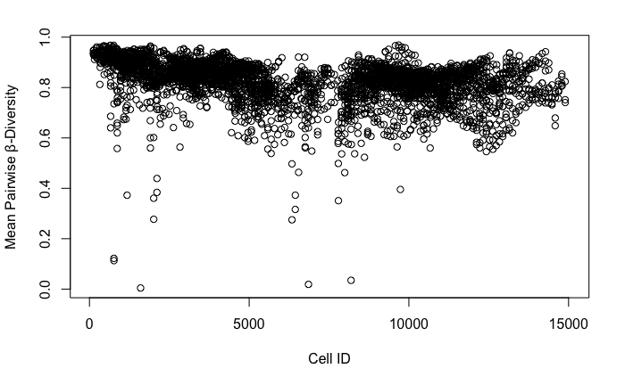

```r
Beta7Vec<-unlist(Beta7)
Beta8Vec<-unlist(Beta8)

BetaVec <- rep(0, 15038)

BetaVec[Cell8]<-Beta8Vec
BetaVec[Cell7]<-Beta7Vec
BetaVec[BetaVec==0]<-NA

plot(BetaVec, ylab = "Mean Pairwise β-Diversity", xlab = "Cell ID")
```

We then mapped these values onto the blank raster and found that the extreme outliers stretch the color gradient, making it difficult to see more intricate variation within the majority of the values.

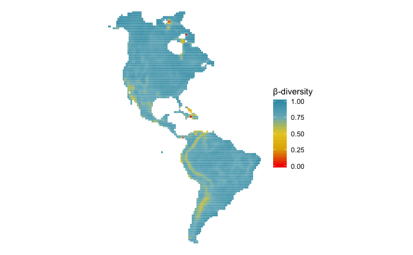

```r
cols <- rev(wes_palette("Zissou1", 500, type = "continuous"))

BetaRaster <- setValues(BlankRas, BetaVec)
BetaDF<-rasterToPoints(BetaRaster)

BetaDF <- data.frame(BetaDF)
colnames(BetaDF) <- c("Longitude", "Latitude", "MAP")

theme_set(theme_void())
RawBetaMap <- ggplot() + geom_tile(data=BetaDF, aes(x=Longitude, y=Latitude, fill=MAP)) +
    scale_fill_gradientn(name="β-diversity", colours=cols, na.value="transparent", limits = c(0,1)) +
    coord_equal()

RawBetaMap
```

In order to combat this issue, we subsetted β-diversity values under 0.5 in order to map them separately in dark grey.

```r
LowBetaVec <- rep(0, 15038)
LowBetaVec[Cell8]<-Beta8Vec
LowBetaVec[Cell7]<-Beta7Vec
LowBetaVec[LowBetaVec==0]<-NA
LowBetaVec[LowBetaVec>0.5]<-NA

LowBetaRaster <- setValues(BlankRas, LowBetaVec)
LowBetaPoints<-rasterToPoints(LowBetaRaster)
LowBetaDF <- data.frame(LowBetaPoints)
colnames(LowBetaDF) <- c("Longitude", "Latitude", "MAP")
```

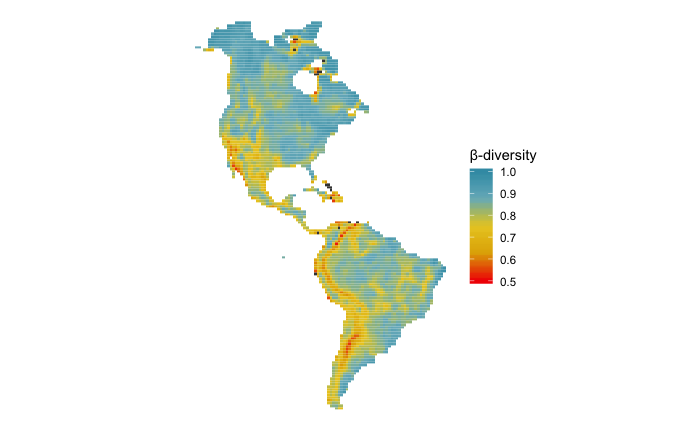

```r
source("Functions/gplot_data.R")
gplotB<- gplot_data(BetaRaster)
gplotLB<- gplot_data(LowBetaRaster)

BetaMap <- ggplot() +
  geom_tile(data = dplyr::filter(gplotLB, !is.na(value)),
            aes(x = x, y = y), fill = "gray25") +
  geom_tile(data = gplotB,
            aes(x = x, y = y, fill = value)) +
  scale_fill_gradientn(name="β-diversity", colours=cols, na.value="transparent", limits = c(0.5,1)) +
  coord_quickmap()
BetaMap
```

Next, we incorporated Carter Powell’s richness map into our study so we would be able to more easily compare α-diversity and β-diversity trends.

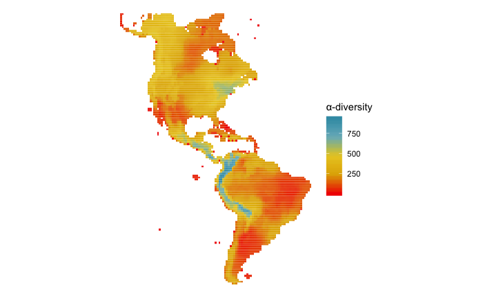

```r
RichnessVec <- readRDS("Data/RichnessVec.rds")
RichnessVec[which(RichnessVec==0)]=NA
RichnessRaster <- setValues(BlankRas, RichnessVec)

RichnessDF <- rasterToPoints(RichnessRaster)
RichnessDF <- data.frame(RichnessDF)

colnames(RichnessDF) <- c("Longitude", "Latitude", "MAP")

theme_set(theme_void())
RichnessMap <- ggplot() + geom_tile(data=RichnessDF, aes(x=Longitude, y=Latitude, fill=MAP)) +
    scale_fill_gradientn(name="α-diversity", colours=cols, na.value="transparent") +
    coord_equal()
RichnessMap
```

We then mapped the α-diversity and β-diversity side-by-side in order visualize the differences in their trends.

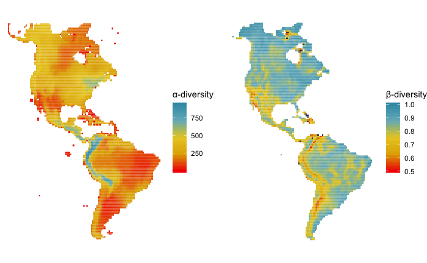

```r
grid.arrange(RichnessMap, BetaMap, ncol=2)
```

Finally, we did the same calculations using the Sorenson similarity index to see how it compared to the Jaccard similarity index. The “SorBetaVec.rds” can be loaded into the code initially and used to create maps using the Sorenson similarity index rather than the Jaccard similarity index.

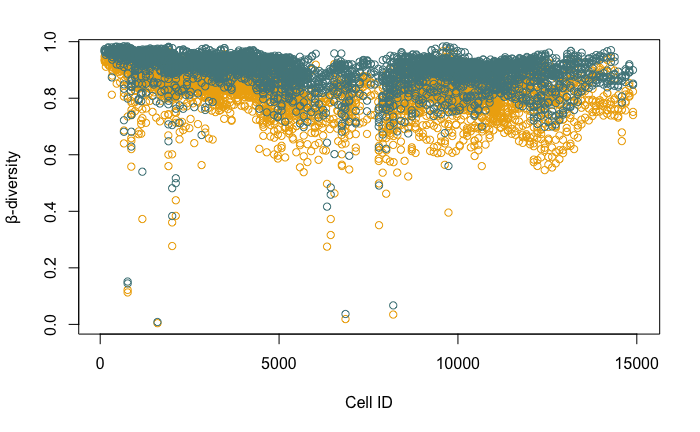

```r
SorBetaVec <- readRDS("Data/SorBetaVec.rds")
SorBetaVec[SorBetaVec<0]<-NA
BetaVec[BetaVec<0]<-NA

plot(BetaVec, ylab = "β-diversity", xlab = "Cell ID", col="darkgoldenrod2")
points(SorBetaVec, col="cadetblue4")
```